# Logistic Regression

Hughes, O’Connell, Wang

Sections A,C: Monday, November 18, 2019 Section B: Thursday, November 21, 2019

# Review: Last session

- What is odds?
- What is an odds ratio?
- What is the benefit of considering log odds?

We hinted at logistic regression last session. This session, we formally introduce it through an example. But we will start today by introducing the concept of generalized linear models.

# Generalized Linear Models

For most of this course, we have been focused on linear models (`lm`). One of the key assumptions we have been making with linear models is that the residuals are normally distributed. But not all models are based on normally distributed errors.

Generalized linear models (`glm`) allow for other types of error distributions. GLMs consist of two additional components:

- Link function: “links” the linear model to the response variable
- Family: the distribution of the response variable

Linear regression is a special case of GLM with

- Link: Identity, $f(x)=x$
- Family: Normal Disribution

Logistic regression is another type of GLM. In this case:

- Link: log odds, $f(p)=\log\left(\frac{p}{1-p}\right)$
  - This is also called the logit function
- Family: Binomial Distribution

We will cover another type of GLM, Poisson regression.

# Logistic Regression Example - Spiders!

## Data Description

The paper “Sexual Cannibalism and Mate Choice Decisions in Wolf Spiders: Influence of Male Size and Secondary Sexual Characteristics” (Animal Behaviour [2005]: 83-94) described a study in which researchers were interested in variables that might be related to a female wolf spider’s decision to kill and consume her partner during courtship or mating. The accompanying data (approximate values read from a graph in the paper) are values of difference in body width (female - male) and whether cannibalism occurs, coded as 0 for no cannibalism and 1 for cannibalism for 52 pairs of courting wolf spiders.

Source: “Introduction to Statistics and Data Analysis” by Roxy Peck, Chris Olsen, Jay L. Devore.

## Some visualization

We have a binary response (cannibalism or not) and a single covariate (continuous variable, difference in size), so this allows us to be creative with visual displays. Below are two examples:

```r
spider <- read.csv("spiderCannibalism.csv")
tail(spider)
```

```
##    SizeDiff Cannibalism
## 47      1.0           1
## 48      1.2           0
## 49      1.4           0
## 50      1.6           1
## 51      1.8           1
## 52      2.0           1
```

Note the response variable, `Cannibalism` is recorded as a 1 or 0. Treating this as a numeric variable has some benefits for certain plots. For other plots, we may want to treat it as a category, so I make a ‘copy’. An example is below:

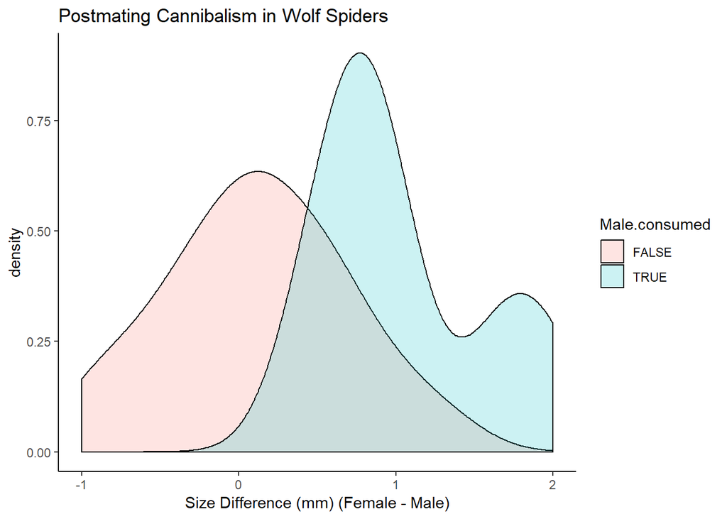

```r
spider <- spider %>% mutate(Male.consumed=as.logical(Cannibalism))
ggplot(spider) +
  geom_density(aes(SizeDiff, fill=Male.consumed), alpha=0.2)+
  labs(x="Size Difference (mm) (Female - Male)",
       title="Postmating Cannibalism in Wolf Spiders") +
  theme_classic()
```

In the above plot, I segment my data into two groups (those where cannibalism occured and those without) and look at the distribution of the size difference variable. This provides some insight into what is happening. Notice we see that the `Male.consumed` group generally has larger size differences than the group where the male was not eaten. Keep in mind here that in this plot we are looking at things backward (essentially how does $Y$ influence $X$).

Another way to visualize this data is the following:

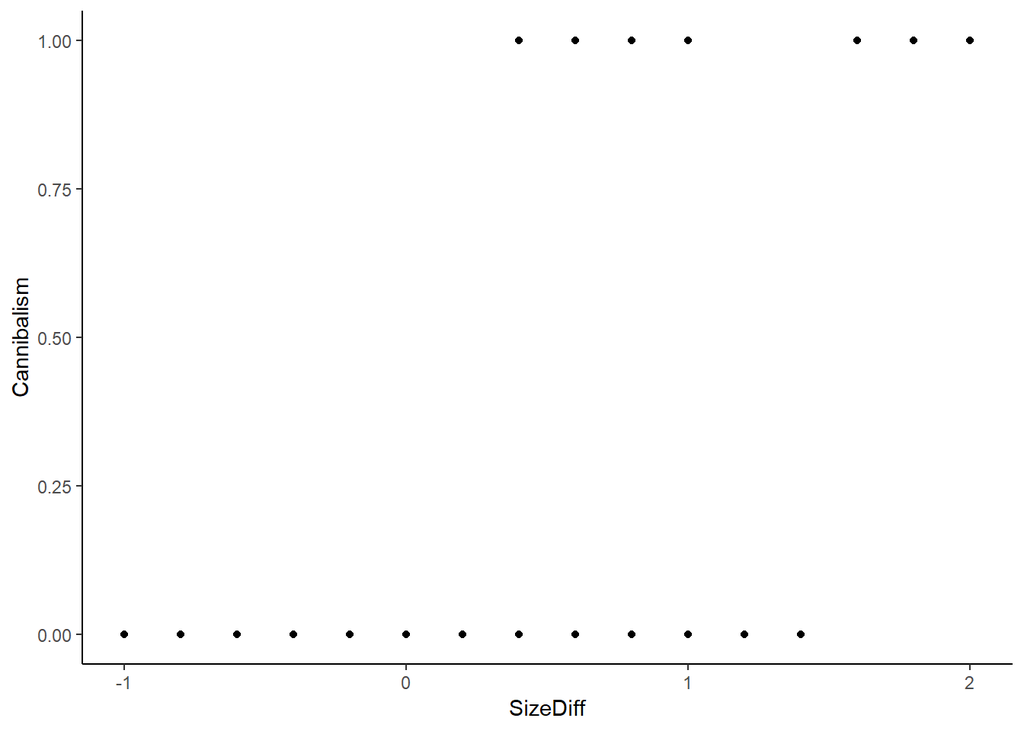

```r
ggplot(spider) +
  geom_point(aes(x=SizeDiff, y=Cannibalism) ) +
  theme_classic()
```

Here we use the numeric variable, `Cannibalism`, compared to the categorical version `Male.consumed` above. Thus we get 1 and 0 values on the plot. We also note it is difficult to parse out the individual observations – due to rounding of the size differences, many points are stacked on top of one another. One graphical way to handle this is with *jittering* – wherein we add a little bit of randomness.

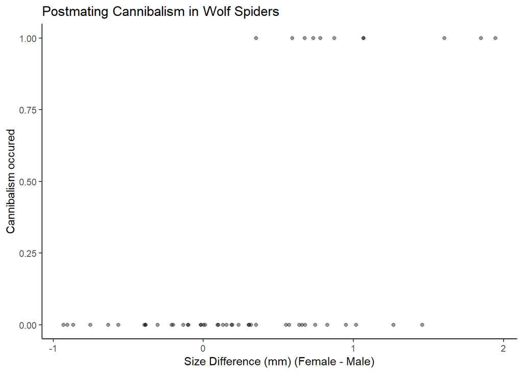

```r
ggplot(spider) +
  geom_jitter(aes(x=SizeDiff, y=Cannibalism), height=0, width=0.1, alpha=0.4) +
  labs(x="Size Difference (mm) (Female - Male)",
       y="Cannibalism occured",
       title="Postmating Cannibalism in Wolf Spiders") +
  theme_classic()
```

Note the use of `geom_jitter` instead of `geom_point`. Although the `sizeDiff` variable is continuous, in the data it has been discretized (rounded to closest first decimal in increments of 2). By adding the jittering option (which basically adds some randomness to my observations), it spreads out the data (visually) so you can see some separation. I also use the `alpha` scaling (where overlapping points will show up darker than stand-alone points) option so we can see little clusters. We also clean up the labeling.

Visually it looks like larger size differences result in more cases of spider cannibalism. How can we model this? The answer is Logistic Regression.

## Modeling

How do we model this?

First, let’s recall some material from last session. In this example, our **response** variable is a **binary** outcome (True/False on whether Postmating cannibalism occured). In this sort of experiment, the parameter of interest is $p$ defined as

$$p = P(\textrm{Postmating Cannibalism Occured})$$

Since $p$ is a probaility, or proportion, we know $0 \leq p \leq 1$, and thus standard linear regression is not appropriate. But we saw last session that if we consider the *odds* of cannibalism,

$$odds = \frac{p}{1-p}$$

we are now working in the domain $(0, \infty)$. Further, if we consider the logarithm of the odds, that is $\log\left(\frac{p}{1-p}\right)$, we are working in the domain $(-\infty, \infty)$. Thus, linear regression is more valid when working with the log-odds, so we could consider the model

$$logit(p) = \log\left(\frac{p}{1-p}\right) = \beta_0 + \beta_1 X$$

Last session, we worked through an example modeling prevelence of heart disease as a function of BMI. Here, we want to do the same thing! In terms of $p$, the above model can be written as

$$p = \frac{\exp\left(\beta_0 + \beta_1 X\right)}{1 + \exp\left(\beta_0 + \beta_1 X\right)}$$

The above is known as a *logistic* equation. This is why this is called *logistic regression*.

### Modeling in R

To fit a logistic regression in R we use the `glm` function, which stands for **Generalized Linear Model**. In our derivation above, we are *generalizing* linear regression to work with some function (known as the *link* function) of the data (in this example a logistic regression). Below is how we fit our model

```r
spider.fit <- glm(Cannibalism ~ SizeDiff, data=spider, family=binomial(link=logit))
```

That’s it! The code is very similar to our `lm()` and `aov()` code from before. The key thing with `glm()` is we need to specify the distribution of the response (the family). We can also specify the link function (this is technically not necessary here because `link=logit` is the default behavior for the binomial family), in this example that is `family=binomial`.

We can then explore the output of the fitted model:

```r
summary(spider.fit)
```

```
##
## Call:
## glm(formula = Cannibalism ~ SizeDiff, family = binomial(link = logit),
##     data = spider)
##
## Deviance Residuals:
##     Min       1Q   Median       3Q      Max
## -1.7143  -0.5376  -0.2985  -0.0825   2.0029
##
## Coefficients:
##             Estimate Std. Error z value Pr(>|z|)
## (Intercept)  -3.0890     0.8288  -3.727 0.000194 ***
## SizeDiff      3.0693     1.0041   3.057 0.002237 **
## ---
## Signif. codes:  0 '***' 0.001 '**' 0.01 '*' 0.05 '.' 0.1 ' ' 1
##
## (Dispersion parameter for binomial family taken to be 1)
##
##     Null deviance: 53.663  on 51  degrees of freedom
## Residual deviance: 34.721  on 50  degrees of freedom
## AIC: 38.721
##
## Number of Fisher Scoring iterations: 6
```

We see the output is very similar to the `lm()` function we have used throughout the semester. Below we describe important facts about the output.

### Interpretation of parameters

- $\hat{\beta_0}$ = -3.0890444
  - Negative, so when size difference = 0, log-odds of cannibalism will be negative
  - This means the odds are less than 1
  - So the probability of cannibalism when there is no size difference is less than 0.5
  - Specifically, the odds is $\frac{p}{1-p} = \exp(\beta_0)$ = 0.0455455 which is another way of saying the probability of cannibalism when there is no size difference is 0.0435614.
  - So if the spiders are the same size, there is only about a 4% chance the female will kill and eat the male spider.
- $\hat{\beta_1}$ = 3.0692809
  - Positive, so larger size difference leads to more cannibalism
  - For every 1 unit increase in size difference, we would expect the log odds to increase by 3.0692809 units.
  - This gets a little weird when you try to interpret in terms of the the probability, since we are modeling the log odds

Think back to Algebra: sums of logs are multiplication of exp terms, so all increases are relative to the *intercept* term. The odds $\frac{p}{1-p}$ will grow at a multiplicative rate of 21.526418 units.

**Further discussion** – So if the female is 1 unit larger than the size, we basically have the intercept and slope cancelling out (-3 + 3 = 0), and this results in a log odds of 0, which corresponds to the odds of 1, and a probability of 0.5 for cannibalism to occur.

**Other considerations**: Note an AIC value is reported in the `summary()` output. It works just as before! We also see $z$-tests and corresponding $p$-values. These are known as the Wald tests for parameter significance.

The “deviance” values are essentially measures of variability. The “Null deviance” can be considered the variability in the original data, whereas the “Residual deviance” can be considered the variability in the residuals. Using these values, we can construct Pseudo-R-squared values and a model comparison similar to an $F$-test (done below).

Many of the methods we have learned throughout the semester are still valid: predictive modeling, variable selection, etc… Some of these topics will be explored below.

### Statistical Inference – Testing

Note in the summary output, a $Z$-test for the significance of each of the variables is provided. Here we see that the size difference between spiders appears to be a significant influence on the probability of cannibalism occuring in these spiders.

We can also test the significance with an ANOVA-type test (technically it is not ANOVA, it is $\chi^2$ likelihood ratio test (LRT), but works similarly). We use the `anova()` function with the Chi-square test option.

```r
anova(spider.fit, test="LRT")
```

```
## Analysis of Deviance Table
##
## Model: binomial, link: logit
##
## Response: Cannibalism
##
## Terms added sequentially (first to last)
##
##
##          Df Deviance Resid. Df Resid. Dev  Pr(>Chi)
## NULL                        51     53.663
## SizeDiff  1   18.942        50     34.721 1.348e-05 ***
## ---
## Signif. codes:  0 '***' 0.001 '**' 0.01 '*' 0.05 '.' 0.1 ' ' 1
```

Note the $p$-value is different than that reported in the $Z$-test. The Wald test is generally known to be statistically conservative (less Type I errors than is acceptable). You’ll note the $Z$-test $p$-value is larger than the LRT.

We can also perform ANOVA type testing comparing models. In the below example we compare a Null (no $x$-term) model with the fitted model.

```r
spider.nofit <- glm(Cannibalism~1, data=spider, family=binomial(link=logit))
summary(spider.nofit)
```

```
##
## Call:
## glm(formula = Cannibalism ~ 1, family = binomial(link = logit),
##     data = spider)
##
## Deviance Residuals:
##     Min       1Q   Median       3Q      Max
## -0.6895  -0.6895  -0.6895  -0.6895   1.7626
##
## Coefficients:
##             Estimate Std. Error z value Pr(>|z|)
## (Intercept)  -1.3157     0.3396  -3.875 0.000107 ***
## ---
## Signif. codes:  0 '***' 0.001 '**' 0.01 '*' 0.05 '.' 0.1 ' ' 1
##
## (Dispersion parameter for binomial family taken to be 1)
##
##     Null deviance: 53.663  on 51  degrees of freedom
## Residual deviance: 53.663  on 51  degrees of freedom
## AIC: 55.663
##
## Number of Fisher Scoring iterations: 4
```

```r
anova(spider.nofit, spider.fit, test="LRT")
```

```
## Analysis of Deviance Table
##
## Model 1: Cannibalism ~ 1
## Model 2: Cannibalism ~ SizeDiff
##   Resid. Df Resid. Dev Df Deviance  Pr(>Chi)
## 1        51     53.663
## 2        50     34.721  1   18.942 1.348e-05 ***
## ---
## Signif. codes:  0 '***' 0.001 '**' 0.01 '*' 0.05 '.' 0.1 ' ' 1
```

This test tells us that the size difference does influence the probability of cannibalism occuring. You will also note this is the same as the above result except here it is comparing the two models (much like the partial, or reduced, $F$-test for regression).

### Inference – Confidence Intervals

We can also find confidence intervals on our esimated parameter values:

```r
confint(spider.fit)
```

```
##                 2.5 %    97.5 %
## (Intercept) -5.099183 -1.746754
## SizeDiff     1.440142  5.502001
```

It is **important** to consider the interpretation of these confidence intervals. These are coeffecients for the model on the log odds. If I want to get rid of the log part, I need to take exponents.

```r
exp(confint(spider.fit))
```

```
##                   2.5 %     97.5 %
## (Intercept) 0.006101729   0.174339
## SizeDiff    4.221296015 245.182041
```

So a one unit change in size difference will increase the odds of cannibalism by between 4.22 and 245.18 (huge range). But is important to note this change is all relative to the intercept. So a one unit increase in size may increase the odds by 245 times, but the original odds were 0.006 to 0.173. So even in the most extreme case (in terms of 95% confidence intervals), a one unit increase will increase the odds from 0.1743 to 42.7 ($0.174\times 245$).

How does that effect the probability? Good luck! We can complete the inverse logit transformation using the formula above

```r
exp(confint(spider.fit))/(1+exp(confint(spider.fit)))
```

```
##                   2.5 %    97.5 %
## (Intercept) 0.006064723 0.1484571
## SizeDiff    0.808476670 0.9959380
```

We see a range of probabilities but interpretation is quite difficult here. The intercept has interpretation since this corresponds to no size difference, where the probability of cannibalism is between 0.006 and 0.148. However, the size difference coefficient is pretty much meaningless here since the original model has been transformed so much.

### Fitted plot

Technically our response is the log odds. If we wanted to make a “fitted” plot we need to transform the output from the predict function.

```r
predict(spider.fit)
```

```
##           1           2           3           4           5           6
## -6.15832532 -6.15832532 -5.54446913 -5.54446913 -4.93061295 -4.93061295
##           7           8           9          10          11          12
## -4.31675676 -4.31675676 -4.31675676 -4.31675676 -3.70290058 -3.70290058
##          13          14          15          16          17          18
## -3.70290058 -3.70290058 -3.08904439 -3.08904439 -3.08904439 -3.08904439
##          19          20          21          22          23          24
## -3.08904439 -3.08904439 -2.47518821 -2.47518821 -2.47518821 -2.47518821
##          25          26          27          28          29          30
## -2.47518821 -2.47518821 -1.86133202 -1.86133202 -1.86133202 -1.86133202
##          31          32          33          34          35          36
## -1.86133202 -1.24747584 -1.24747584 -1.24747584 -1.24747584 -1.24747584
##          37          38          39          40          41          42
## -1.24747584 -1.24747584 -0.63361965 -0.63361965 -0.63361965 -0.63361965
##          43          44          45          46          47          48
## -0.63361965 -0.01976346 -0.01976346 -0.01976346 -0.01976346  0.59409272
##          49          50          51          52
##  1.20794891  1.82180509  2.43566128  3.04951746
```

Here we see the output is the log-odds (see both negative and positive values). We can get predicted probabilites with a minor change to the code.

```r
predict(spider.fit, type="response")
```

```
##           1           2           3           4           5           6
## 0.002111326 0.002111326 0.003893797 0.003893797 0.007170291 0.007170291
##           7           8           9          10          11          12
## 0.013167395 0.013167395 0.013167395 0.013167395 0.024058822 0.024058822
##          13          14          15          16          17          18
## 0.024058822 0.024058822 0.043561432 0.043561432 0.043561432 0.043561432
##          19          20          21          22          23          24
## 0.043561432 0.043561432 0.077615987 0.077615987 0.077615987 0.077615987
##          25          26          27          28          29          30
## 0.077615987 0.077615987 0.134547870 0.134547870 0.134547870 0.134547870
##          31          32          33          34          35          36
## 0.134547870 0.223137390 0.223137390 0.223137390 0.223137390 0.223137390
##          37          38          39          40          41          42
## 0.223137390 0.223137390 0.346690247 0.346690247 0.346690247 0.346690247
##          43          44          45          46          47          48
## 0.346690247 0.495059295 0.495059295 0.495059295 0.495059295 0.644303654
##          49          50          51          52
## 0.769935830 0.860782583 0.919506544 0.954761689
```

Now all values are between 0 and 1.

Technically, a logistic function is a smooth S-curve. If we plotted the above values it would look fairly jagged, so to get a smooth curve we create a new dataset with many SizeDiff values (we did this before with log/exp of linear models) and then just run the predict function on these values. By default, the predict function outputs logs of odds so we specify `type="response"`.

```r
spider.fit.plot.data <- data.frame(SizeDiff=seq(-1.2, 2.2, 0.01))
spider.fit.plot.data <- spider.fit.plot.data %>%
  mutate(Predicted.Prob = predict(spider.fit, newdata=spider.fit.plot.data, type="response"))

head(spider.fit.plot.data)
```

```
##   SizeDiff Predicted.Prob
## 1    -1.20    0.001143884
## 2    -1.19    0.001179495
## 3    -1.18    0.001216214
## 4    -1.17    0.001254074
## 5    -1.16    0.001293111
## 6    -1.15    0.001333362
```

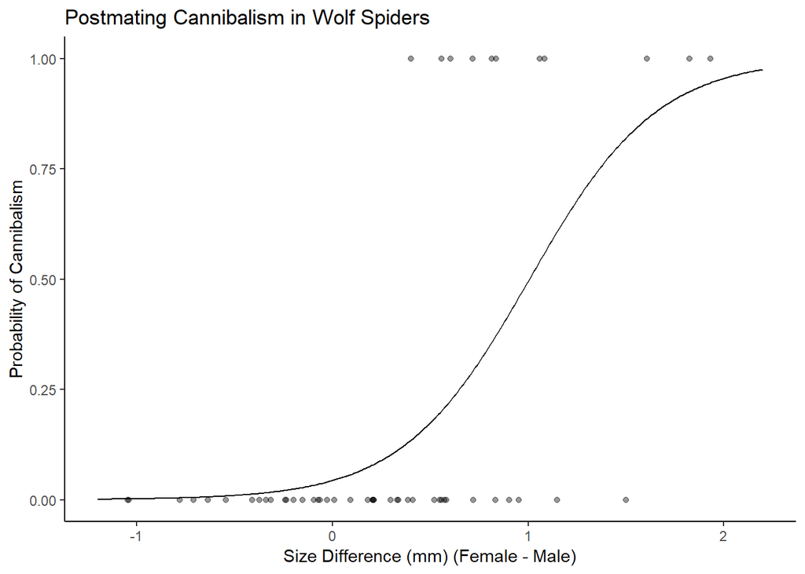

```r
ggplot() +
  geom_jitter(data=spider, aes(x=SizeDiff, y=Cannibalism), height=0, width=0.1, alpha=0.4) +
  geom_line(data=spider.fit.plot.data, aes(x=SizeDiff, y=Predicted.Prob)) +
    labs(x="Size Difference (mm) (Female - Male)",
       y="Probability of Cannibalism",
       title="Postmating Cannibalism in Wolf Spiders") +
  theme_classic()
```

# Some notes about today

- Here we looked at modeling a binary response variable using logistic regression. Alternatively we could use *Probit* regression for binary response (feel free to check out https://en.wikipedia.org/wiki/Probit_model). It works similar to logistic regression and in some cases has a nicer interpretation.
- Can we perform multiple logistic regression? Yes!!! We will look at examples during next lecture.